# SMGR: Setup and Introduction

*SMGR (Joint statistical method for integrative analysis of single-cell multi-omics data)*

Vignette built on April 15, 2022.

**SMGR workflow**

This tutorial goes through the steps in the SMGR workflow:

- Identify conistent signals of genes and peaks based on scRNA-seq & scATAC-seq data.
- Reveal the latent representation of co-expressed genes and peaks, i.e. co-regulatory program
- Identify co-expressed TF and target genes, based on single-cell multi-omics analysis

The setup and running steps are shown as follows in this tutorial:

**Requirements**

- Input: expression matrix The input to SMGR is a list of scRNA-seq expression matrix and scATAC-seq matrix:

*For scRNA-seq matrix:* Each column corresponds to a sample (cell) and each row corresponds to a gene. Expression units: The preferred expression values are gene-summarized raw counts. Other measurements (such as FPKM) are also accepted.

*For scATAC-seq matrix:* Each column corresponds to a sample (cell) and each row corresponds to a peak.

# Installation

The R implementation of SMGR is based on R packages as below.

Therefore, you will need to install these packages, and some extra dependencies, to run SMGR:

```r
if (!requireNamespace("BiocManager", quietly = TRUE)) install.packages("BiocManager")
BiocManager::version()
```

```
## [1] '3.12'
```

```r
# If your bioconductor version is previous to 4.0, see the section bellow
# Required
packages = c('glmnet','MASS','purrr','mpath','zic','pscl','parallel')
# BiocManager::install(packages)
```

Now you are ready to install SMGR:

```r
# devtools::install_github("QSong-github/SMGR")
library('SMGR')
```

*Note: please invoke these packages to run the following codes:*

```r
packages = c('glmnet','MASS','purrr','mpath','zic','pscl','parallel')
ipak(packages)
```

```
##   glmnet     MASS    purrr    mpath      zic     pscl parallel
##     TRUE     TRUE     TRUE     TRUE     TRUE     TRUE     TRUE
```

# Run SMGR with example data

Example data is deposited in the data folder.

```r
# @param rna.cts simulated scRNA-seq data
rna.cts <- readRDS('simuation_scRNA-seq.RDS')

# @param atac.cts simulated scATAC-seq data
atac.cts <- readRDS(file='simuation_scATAC-seq.RDS')

input_data <- list(rna.cts, atac.cts)
```

**SMGR process**

Input data is a list of scRNA-seq and scATAC-seq data

```r
input_data <- list(as.matrix(rna.cts),as.matrix(atac.cts))

result1 <- smgr_main(sm.data = input_data, K=nrow(input_data[[1]]))
```

```
## ## ============================================================================
## ## |                             running SMGR                                  |
## ## ----------------------------------------------------------------------------
## ## |            scRNA-seq data and scATAC-seq data identified ....              |
## ## |                           Set initial values ....                         |
## ## |                               iter= 1.....                                |
## ## |                               iter= 2.....                                |
## ## |                               iter= 3.....                                |
## ## |                               iter= 4.....                                |
## ## |                               iter= 5.....                                |
## ## |                               iter= 6.....                                |
## ## |                               iter= 7.....                                |
## ## |                               iter= 8.....                                |
## ## |                               iter= 9.....                                |
## ## |                               iter=10.....                                |
## ## |                               iter=11.....                                |
## ## |                               iter=12.....                                |
## ## |                               iter=13.....                                |
## ## |                               iter=14.....                                |
## ## |                               iter=15.....                                |
## ## |                               iter=16.....                                |
## ## |                               iter=17.....                                |
## ## |                               iter=18.....                                |
## ## |                               iter=19.....                                |
## ## |                               iter=20.....                                |
```

*if output is set to ‘all’, you will obtain the coefficients and BIC values*

```r
# member1: is the ground truth
member1 <- c(rep(1,600),rep(2,600),rep(3,600))

# programs: co-expressed gene & peaks from latent representation
programs <- result1$clusters
```

**report ARI score**

```r
library(clues)
print (adjustedRand(programs, member1))
```

```
##    Rand      HA      MA      FM Jaccard
##       1       1       1       1       1
```

**latent.var** : latent representation of genes & peaks

```r
latent.var <- result1$latent_f
```

**evaluation metrics**

*eval* : evaluation metrics

```r
library(clValid); library(clusterCrit)

eval <- vector('list',length=2)
for ( i in 1:2 ){
    data <- log2(input_data[[i]]+1)
    ind1 <- Evaluate(data,programs)
    ind2 <- intCriteria(data,as.integer(programs),
                        c("Calinski_Harabasz",'Davies_Bouldin'))
    inds <- as.data.frame(rbind(do.call(rbind,ind2),ind1))
    if (i==1){ inds$data <- 'scRNA-seq' } else { inds$data <- 'scATAC-seq' }
    colnames(inds) <- c('metrics','data')
    eval[[i]] <- inds
}
```

*Evaluation index for scRNA-seq data*

```r
print (eval[[1]])
```

```
##                        metrics      data
## calinski_harabasz 130.00004149 scRNA-seq
## davies_bouldin      4.48195970 scRNA-seq
## Dunn                0.59328525 scRNA-seq
## Sihouette           0.05238342 scRNA-seq
```

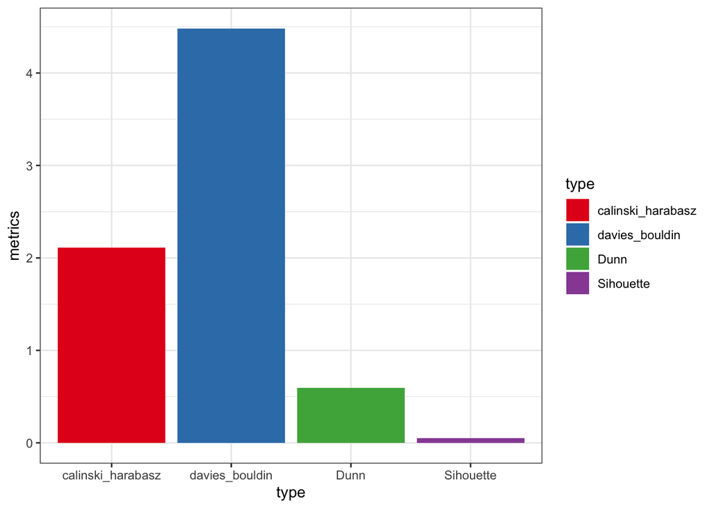

```r
eval[[1]][1,1] = log10(eval[[1]][1,1])
eval[[1]]$type = rownames(eval[[1]])
library(ggplot2)
p <- ggplot(eval[[1]], aes(x=type, y=metrics, fill=type)) +
    geom_bar(stat='identity')+
    scale_fill_brewer(palette='Set1')+ theme_bw()
print (p)
```

*Evaluation index for scATAC-seq data*

```r
print (eval[[2]])
```

```
##                        metrics       data
## calinski_harabasz 130.09797714 scATAC-seq
## davies_bouldin      4.46870408 scATAC-seq
## Dunn                0.59913972 scATAC-seq
## Sihouette           0.05267272 scATAC-seq
```

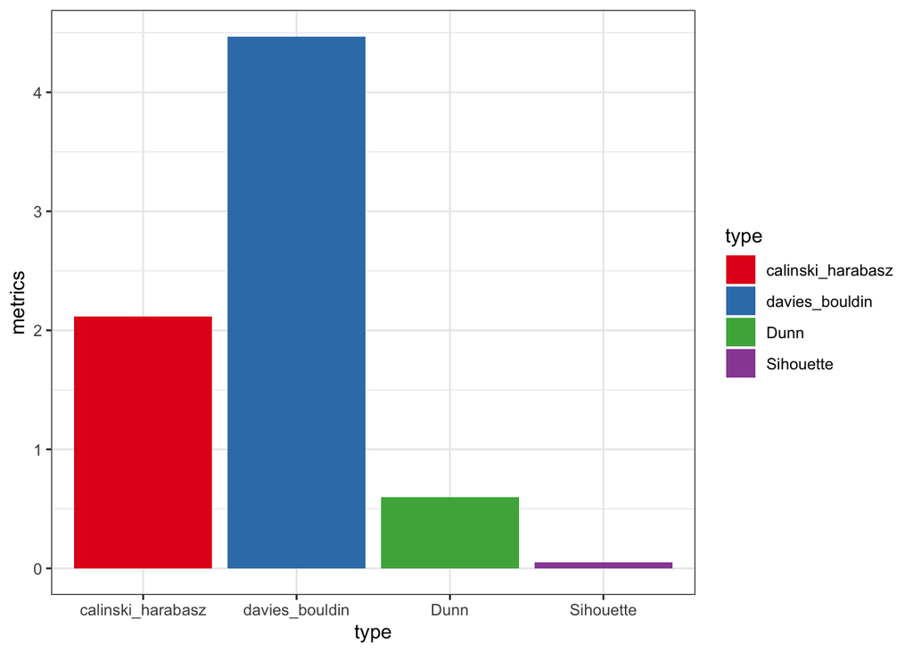

```r
eval[[2]][1,1] = log10(eval[[2]][1,1])
eval[[2]]$type = rownames(eval[[2]])
p <- ggplot(eval[[2]], aes(x=type, y=metrics, fill=type)) +
    geom_bar(stat='identity')+
    scale_fill_brewer(palette='Set1')+ theme_bw()
print (p)
```

**Visualization of results data**

*for scRNA-seq data*

```r
library(ComplexHeatmap)
d1 <- log2(input_data[[1]]+1)
```

*Suppose these programs are identified in differnt cell types*

```r
m1 <- d1[programs==1,]; m2 <- d1[programs==2,]; m3 <- d1[programs==3,]
program.d <- rbind(cbind(m1,matrix(0,nrow=nrow(m1),ncol=400)),
                   cbind(matrix(0,nrow=nrow(m2),ncol=200),m2,matrix(0,nrow=nrow(m2),ncol=200)),cbind(matrix(0,nrow=nrow(m3),ncol=400),m3))
```

*color setting*

```r
library(circlize)
c1 <- c("#EDEDEDFF","dodgerblue"); c1 <- c("#EDEDEDFF","#FF7043FF")
myCol1 <- colorRampPalette(c1)(100); myBreaks1 <- seq(0, 4, length.out = 100)
```

**Heatmap**

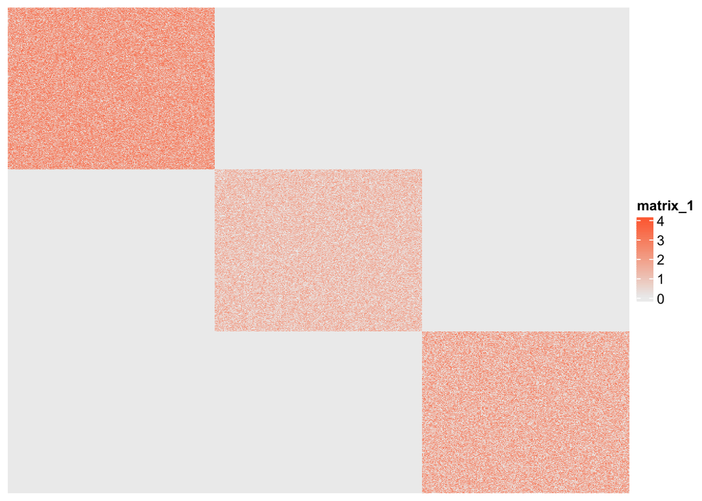

```r
print (Heatmap(program.d,
               cluster_columns = FALSE,cluster_rows =F,
               show_column_names = FALSE,show_row_names=FALSE,
               col = colorRamp2(myBreaks1, myCol1)))
```

# Run SMGR with your own data

For your own real data: here we use the simulated toy data to demonstrate the process

```r
#devtools::install_github("bowang-lab/simATAC")
library(simATAC);
count <- getCountFromh5("GSE99172.snap")  # GSE99172.snap is accessbile from simATAC package: https://data.wanglab.ml/simATAC/GSE99172.snap
obj1 <- simATACEstimate(t(count))
obj1 <- setParameters(obj1, noise.mean = -0.3, noise.sd = 0.1)
obj1 <- simATACSimulate(obj1, nCells = 200)
```

the .gtf file can be downloaded from https://grch37.ensembl.org/info/data/ftp/index.html

*map the link between peak regions and genes:*

```r
# atac.cts: toy scATAC data
atac.cts = linkActivityMatrix(peak.matrix = counts(obj1)[1:6000,1:200],
                           annotation.file = 'Homo_sapiens.GRCh37.82.gtf',
                           seq.levels = c(1:22,'X','Y'),
                           upstream = 2000)$activity_matrix[1:600,1:200]

# rna.cts: toy scRNA-seq data
library(splatter); library(scater)
sim.groups <- splatSimulate(group.prob =1, method = "groups",
                            verbose = FALSE, nGenes=600, batchCells=200)
rna.cts <- counts(sim.groups)
rownames(rna.cts) <- rownames(atac.cts);
colnames(rna.cts) <- paste0('cell_',1:ncol(rna.cts))
```

input_data: with a list of scRNA-seq and scATAC-seq toy data

```r
input_data <- list(rna.cts, atac.cts)
```

*from here, you can start with the smgr function and use the evaluation index to check if you achieve good performance of idnetifying co-regulation program*

```r
library(SMGR)
result1 <- smgr_main(sm.data = input_data, K=nrow(input_data[[1]]))
```

```
## ## ============================================================================
## ## |                             running SMGR                                  |
## ## ----------------------------------------------------------------------------
## ## |            scRNA-seq data and scATAC-seq data identified ....              |
## ## |                           Set initial values ....                         |
## ## |                               iter= 1.....                                |
## ## |                               iter= 2.....                                |
## ## |                               iter= 3.....                                |
## ## |                               iter= 4.....                                |
## ## |                               iter= 5.....                                |
## ## |                               iter= 6.....                                |
## ## |                               iter= 7.....                                |
## ## |                               iter= 8.....                                |
## ## |                               iter= 9.....                                |
## ## |                               iter=10.....                                |
## ## |                               iter=11.....                                |
## ## |                               iter=12.....                                |
## ## |                               iter=13.....                                |
## ## |                               iter=14.....                                |
## ## |                               iter=15.....                                |
## ## |                               iter=16.....                                |
## ## |                               iter=17.....                                |
## ## |                               iter=18.....                                |
## ## |                               iter=19.....                                |
## ## |                               iter=20.....                                |
```